# Modello Gaussiano: misurazione del FEV1

NikolayNikolaev

2023-05-29

# Modello Gaussiano: misurazione del FEV1

Occorre stimare il volume medio di aria che può essere espirato con uno sforzo massimale in un secondo (FEV1) a seguito dell’assunzione di un farmaco per l’asma. Questo consente di valutare la capacità dei bronchi.

Si noti che nel seguente esempio si considera l’inferenza sulla media della popolazione condizionata al valore noto dalla varianza della popolazione.

## Specificazione dei parametri della distribuzione a priori

Si determinano i parametri della distribuzione di Gauss che soddisfano le conoscenze espresse dall’azienda farmaceutica. Utilizzando la funzione learnBayes::normal.select con i quantili di riferimento si ottengono i parametri della distribuzione a priori $p(\theta) = N(\mu, \tau^2)$

```r
quantile1 <- list(p = 0.05, x=100); quantile1
```

```
## $p
## [1] 0.05
##
## $x
## [1] 100
```

```r
quantile2 <- list(p = 0.7, x=180); quantile2
```

```
## $p
## [1] 0.7
##
## $x
## [1] 180
```

La funzione normal.select restituisce i valori dei due parametri (media e deviazione standard) della distribuzione di Gauss che rispettano i vincoli imposti

```r
require(LearnBayes)
normal.select(quantile1, quantile2)
```

```
## $mu
## [1] 160.6606
##
## $sigma
## [1] 36.87904
```

la distribuzione a priori per il parametro che rappresenta il volume medio espirato in un secondo è ha i seguenti iperparametri $N(161, 37^2)$

## Informazioni campionarie

Disponendo di 31 rilevazioni effettuate su un campione di pazienti a seguito dell’assunzione del farmaco si osserva un valore medio pari a 135 e si suppone che la deviazione standard nella popolazione sia pari a 12 (ovviamente anche questo parametro potrebbe essere stimato, ma per il momento lo consideriamo noto). Pertanto $f(\bar{x}, \theta, \sigma^2) = N(\theta, \freq{\sigma^2}{n})$

## Distribuzione a posteriori

La distribuzione a posteriori è $p(\theta|x) = N(\mu_1, \tau_1^2)$. La stima del valore attesso e’:

```r
n <- 31
mu1<- (161*12^2 + (n*135*37^2))/(n*37^2 + 12^2); mu1
```

```
## [1] 135.0879
```

con 𝜇$\mu_1$ media ponderta della media a priori e della media campionaria. Mentre la varianza della distribuzione a posteriori è

```r
tau12<- ((37^2)*12^2)/(n*37^2+12^2);
tau12
```

```
## [1] 4.629453
```

```r
tau1<-sqrt(tau12)
# or
1/(31/12^2 + 1/37^2)
```

```
## [1] 4.629453
```

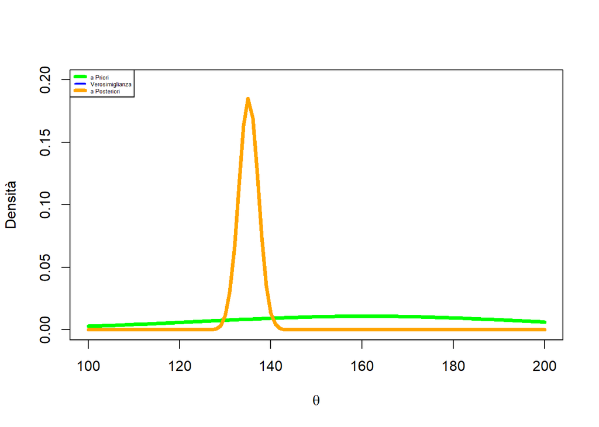

```r
# distribuzione a priori
mu <- 161
tau <- 37
curve(dnorm(x,mu,tau),
      xlab = expression(theta),
      ylab="Densità",
      xlim=c(100,200),
      ylim = c(0,0.2),
      lwd=4,
      col="green")
n<-31
# verosimiglianza
xbar <- 135
sigma <- 12
ss<-sigma/sqrt(n)
curve(dnorm(x,xbar,ss),
    lwd=2,
    col= "blue",
    add=TRUE)
# distribuzione a posteriori
curve(dnorm(x,mu1,tau1),
    lwd=4,
    col="orange",
    add=TRUE)
legend("topleft",
      c("a Priori","Verosimiglianza","a Posteriori"),
      lwd=c(4,2,4),
      cex = 0.4,
      col=c("green", "blue","orange" ))
```

Dato che la distribuzione iniziale non è molto informativa (la variabilità è piuttosto elevata, prior piatta) la distribuzione delle osservazioni è quella che determina il valore medio a posteriori.

## Prior maggiormente informativa

Supponendo una distribuzione iniziale più informativa (con ridotta variabilità rispetto alla precedente, ovvero maggiormente concentrata intorno alla media): $𝑁 (161, 1)$ si ottengono le seguenti stime per i parametri della distribuzione a posteriori

```r
mu1 <- (161*12^2 + (n*135*1^2))/(n*1^2 + 12^2); mu1
```

```
## [1] 156.3943
```

```r
tau12 <- ((1^2)*12^2)/(n*1^2+12^2);
tau12
```

```
## [1] 0.8228571
```

```r
tau1 <-sqrt(tau12)
```

## Rappresentazione grafica: scenario 2

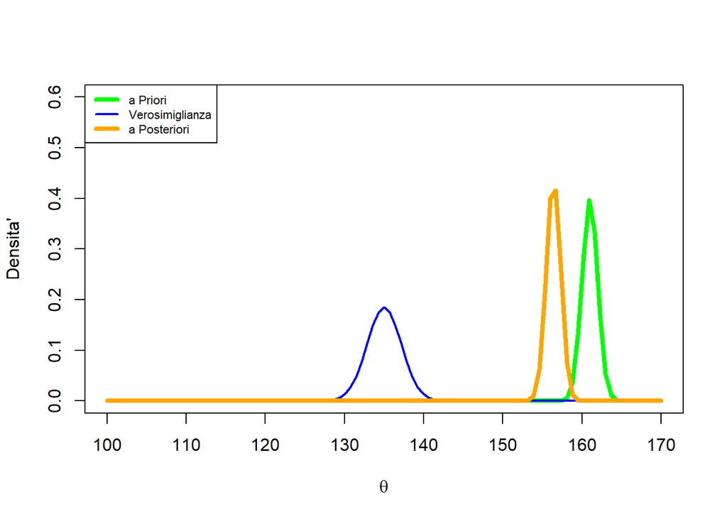

```r
# distribuzione a priori
mu <- 161
tau <- 1
curve(dnorm(x,mu,tau),
    xlab= expression(theta),
    ylab="Densita'",
    xlim=c(100,170),
    ylim = c(0,0.6),
    lwd=4,
    col="green")
# verosimiglianza
sigma <- 12
n<-31
ss<-sigma/sqrt(n)
curve(dnorm(x,xbar,ss),
    lwd=2,
    col= "blue",
    add=TRUE)
# distribuzione a posteriori
curve(dnorm(x,mu1,tau1),
    lwd=4,
    col="orange",
    add=TRUE)
legend("topleft",
    c("a Priori","Verosimiglianza","a Posteriori"),
    lwd=c(4,2,4),
    col=c("green", "blue","orange" ), cex = 0.7)
```

Il peso delle osservazioni campionarie si è notevolmente ridotto in quanto la prior è particolarmente informativa. La distribuzione a posteriori ha una media molto più vicina a quella della distribuzioni a priori e presenta sempre minima variabilità. ## Numerosità campionaria ridotta Si considera lo scenario 1 con distribuzione a priori poco informativa e si suppone di disporre di un campione ancora più piccolo con numerosità $𝑛 = 6$. Le stime dei parametri della distribuzione a posteriori diventano

```r
n1 <- 6
mu11<- (161*12^2 + (n1*135*37^2))/(n1*37^2 + 12^2); mu11
```

```
## [1] 135.448
```

```r
tau121<- ((37^2)*12^2)/(n1*37^2+12^2);
tau121
```

```
## [1] 23.5865
```

```r
tau11<-sqrt(tau121)
```

Si confrontano le figure rispetto al caso precedente di $𝑛 = 31$

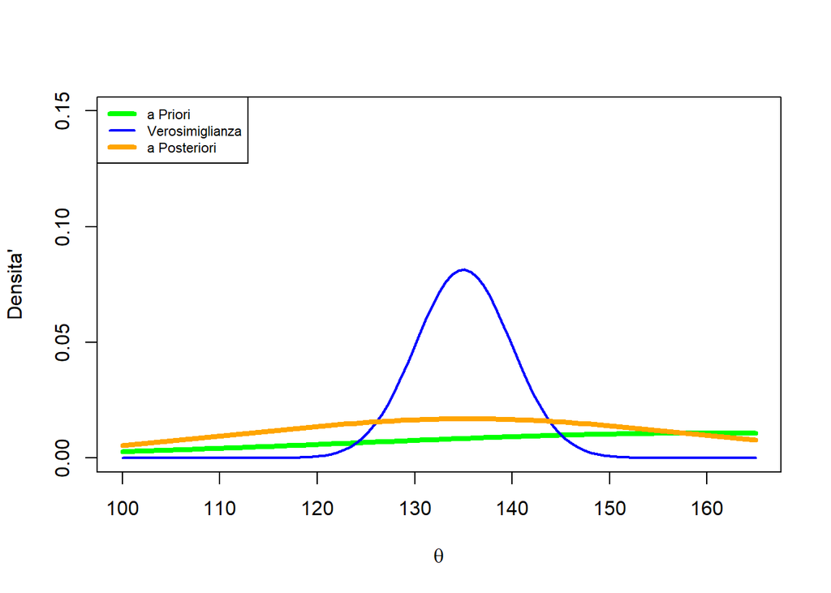

```r
# distribuzione a priori
mu <- 161
tau <- 37
curve(dnorm(x,mu,tau),
      xlab = expression(theta),
      ylab="Densita'",
      xlim=c(100,165),
      ylim = c(0,0.15),
      lwd=4,
      col="green")
# verosimiglianza
sigma <- 12
ss<-sigma/sqrt(n1)
curve(dnorm(x,xbar,ss),
    lwd=2,
    col= "blue",
    add=TRUE)
# distribuzione a posteriori
curve(dnorm(x,mu11,tau121),
    lwd=4,
    col="orange",
    add=TRUE)
legend("topleft",
    c("a Priori","Verosimiglianza","a Posteriori"),
    lwd=c(4,2,4),
    col=c("green", "blue","orange" ), cex = 0.7)
```

La distribuzione a posteriori come nello scenario 1 è centrata rispetto al valore medio della verosimiglianza essendo la prior non informativa ma dato che la numerosità campionaria è ridotta a parità di altre condizioni la variabilità della distribuzione a posteriori è più elevata. In questo caso la precisione nella stima del parametro è minore.

## Distribuzione Predittiva:

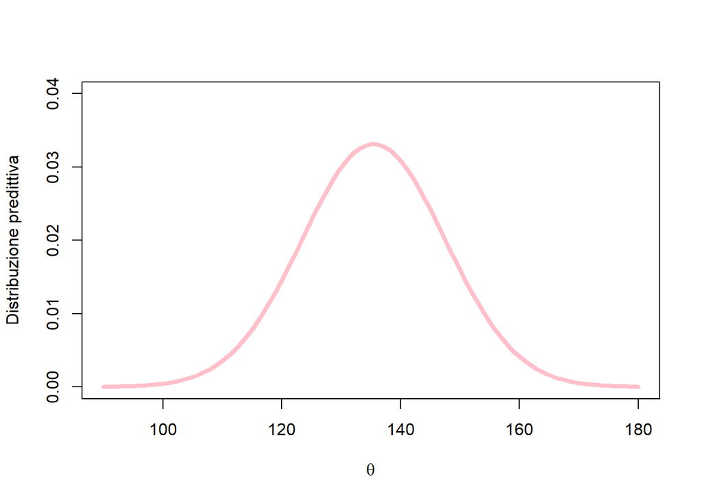

```r
curve(dnorm(x,mu11,sqrt((tau12 + sigma^2))),
    xlab = expression(theta),
    ylab="Distribuzione predittiva",
    xlim=c(90,180),
    ylim = c(0,0.04),
    lwd=4,
    col="pink")
```